# Section 2.11 R Code and Analysis

## The `Birthweight` Data Set Example

The `birthweight.csv` data set contains observations on **42** babies. The variables are:

- `ID`: Unique identification number of the baby
- `Length`: Length of the baby at birth in cm ($X_1$)
- `Birthweight`: Weight of the baby at birth in kg ($Y$)
- `Headcirc`: Head circumference of the baby at birth in cm ($X_2$)
- `Gestation`: Completed weeks of gestation ($X_3$)
- `smoker`: Whether the mother smoked {0: No, 1: Yes} ($X_4$)
- `mage`: Mother’s age at the time of birth ($X_5$)
- `mnocig`: Number of cigarettes the mother smoked per day ($X_6$)
- `mheight`: Mother’s height in cm ($X_7$)
- `mppwt`: Mother’s pre-pregnancy weight ($X_8$)
- `fage`: Father’s age at the time of birth ($X_9$)
- `fedyrs`: Father’s years of education ($X_{10}$)
- `fnocig`: Number of cigarettes the father smoked per day ($X_{11}$)
- `fheight`: Father’s height ($X_{12}$)

```r
birthweight <- read.csv("Birthweight.csv", header = TRUE)
dim(birthweight)
```

```
## [1] 42 14
```

```r
head(birthweight)
```

```
##     ID Length Birthweight Headcirc Gestation smoker mage mnocig mheight mppwt
## 1 1360     56        4.55       34        44      0   20      0     162    57
## 2 1016     53        4.32       36        40      0   19      0     171    62
## 3  462     58        4.10       39        41      0   35      0     172    58
## 4 1187     53        4.07       38        44      0   20      0     174    68
## 5  553     54        3.94       37        42      0   24      0     175    66
## 6 1636     51        3.93       38        38      0   29      0     165    61
##   fage fedyrs fnocig fheight
## 1   23     10     35     179
## 2   19     12      0     183
## 3   31     16     25     185
## 4   26     14     25     189
## 5   30     12      0     184
## 6   31     16      0     180
```

The `ID` variable is not of interest, so we remove it from the data frame:

```r
birthweight <- birthweight[, -1]
```

#### Fitting a Multiple Linear Regression

We begin by fitting a linear regression model that includes all predictors and examine the least-squares summary:

```r
birthweight.mlr.full <- lm(Birthweight ~ ., data = birthweight)
summary(birthweight.mlr.full)
```

```
##
## Call:
## lm(formula = Birthweight ~ ., data = birthweight)
##
## Residuals:
##      Min       1Q   Median       3Q      Max
## -0.37925 -0.25558 -0.05541  0.21700  0.60329
##
## Coefficients:
##              Estimate Std. Error t value Pr(>|t|)
## (Intercept) -3.812311   2.080150  -1.833  0.07713 .
## Length       0.034152   0.031456   1.086  0.28656
## Headcirc     0.086594   0.029489   2.937  0.00644 **
## Gestation    0.096565   0.031323   3.083  0.00447 **
## smoker      -0.243895   0.168516  -1.447  0.15854
## mage        -0.019004   0.018537  -1.025  0.31374
## mnocig       0.001064   0.006854   0.155  0.87770
## mheight      0.004187   0.014153   0.296  0.76944
## mppwt        0.010346   0.011228   0.921  0.36443
## fage         0.007187   0.016327   0.440  0.66305
## fedyrs       0.003220   0.030939   0.104  0.91783
## fnocig       0.003445   0.004013   0.858  0.39769
## fheight     -0.013293   0.009614  -1.383  0.17731
## ---
## Signif. codes:  0 '***' 0.001 '**' 0.01 '*' 0.05 '.' 0.1 ' ' 1
##
## Residual standard error: 0.3342 on 29 degrees of freedom
## Multiple R-squared:  0.7834, Adjusted R-squared:  0.6938
## F-statistic: 8.742 on 12 and 29 DF,  p-value: 1.011e-06
```

The objects returned by `lm` and by `summary(lm(...))` can be inspected with:

```r
names(birthweight.mlr.full)
```

```
##  [1] "coefficients"  "residuals"     "effects"       "rank"
##  [5] "fitted.values" "assign"        "qr"            "df.residual"
##  [9] "xlevels"       "call"          "terms"         "model"
```

```r
names(summary(birthweight.mlr.full))
```

```
##  [1] "call"          "terms"         "residuals"     "coefficients"
##  [5] "aliased"       "sigma"         "df"            "r.squared"
##  [9] "adj.r.squared" "fstatistic"    "cov.unscaled"
```

The design matrix is obtained by

```r
design.birthweight <- model.matrix(birthweight.mlr.full)
```

The estimated regression coefficients (including the intercept) are

```r
birthweight.mlr.full$coef
```

```
##  (Intercept)       Length     Headcirc    Gestation       smoker         mage
## -3.812311183  0.034151922  0.086594329  0.096565435 -0.243895136 -0.019003806
##       mnocig      mheight        mppwt         fage       fedyrs       fnocig
##  0.001064074  0.004187315  0.010346096  0.007187428  0.003219952  0.003444674
##      fheight
## -0.013293205
```

Fitted values and residuals are extracted as

```r
full.model.residuals <- birthweight.mlr.full$resid
full.model.fitted   <- birthweight.mlr.full$fitted
```

**Residual standard error and $R^2$**

The residual variance estimator is

$$\hat{\sigma}^2 = \frac{1}{n-p-1}\sum_i r_i^2 = \frac{RSS}{n-p-1}.$$

We can compute $\hat{\sigma}$ directly

```r
n <- dim(birthweight)[1]
p <- dim(birthweight)[2] - 1
sqrt(sum(birthweight.mlr.full$residuals^2) / (n - p - 1))
```

```
## [1] 0.3341631
```

or extract it from the summary object:

```r
summary(birthweight.mlr.full)$sigma
```

```
## [1] 0.3341631
```

The coefficient of determination is

$$R^2 = 1 - \frac{RSS}{TSS}.$$

It can be read from the summary or computed manually:

```r
summary(birthweight.mlr.full)$r.squared
```

```
## [1] 0.783425
```

```r
1 - sum(birthweight.mlr.full$residuals^2) / (var(birthweight$Birthweight) * (n - 1))
```

```
## [1] 0.783425
```

```r
1 - var(birthweight.mlr.full$residuals) / var(birthweight$Birthweight)
```

```
## [1] 0.783425
```

#### Invariance of $R^2$ and Fitted Values

We verify the invariance property of $R^2$ by centering one of the predictors:

```r
## Center the Length variable
birthweight.new <- birthweight
birthweight.new$Length.new <- birthweight.new$Length - mean(birthweight.new$Length)

## Model with original Length
summary(lm(Birthweight ~ ., data = birthweight.new[-14]))$r.squared
```

```
## [1] 0.783425
```

```r
## Model with centered Length
summary(lm(Birthweight ~ ., data = birthweight.new[-1]))$r.squared
```

```
## [1] 0.783425
```

The fitted values from the two models are essentially identical (any tiny difference is due to floating-point rounding):

```r
sum(fitted(lm(Birthweight ~ ., data = birthweight.new[-14])) -
    fitted(lm(Birthweight ~ ., data = birthweight.new[-1])))
```

```
## [1] -8.881784e-16
```

#### Behavior of $R^2$ and $RSS$ when Predictors Are Added

We illustrate that $R^2$ always increases (and $RSS$ always decreases) when a new predictor is added, even if that predictor is pure noise.

```r
birthweight.new <- birthweight
birthweight.new$randomvar <- rnorm(42)
```

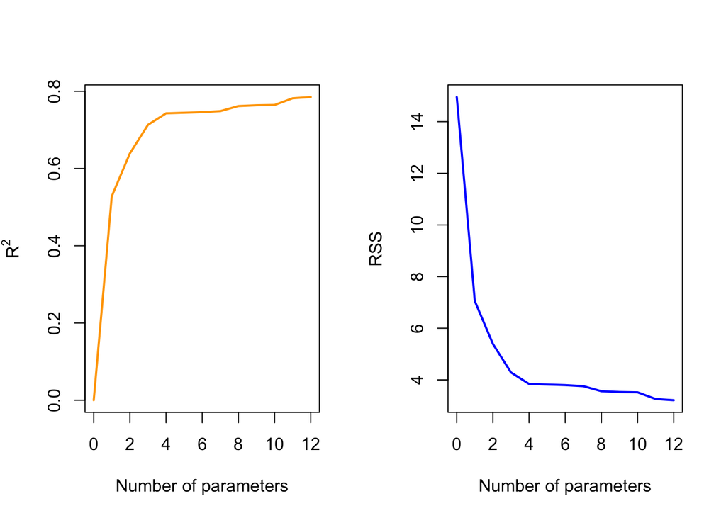

```r
no.var <- 0:12
par(mfrow = c(1, 2))
plot(no.var, rsq, xlab = "Number of parameters", ylab = expression(R^2), type = "n")
lines(no.var, rsq, lwd = 2, col = "orange")
plot(no.var, rss, xlab = "Number of parameters", ylab = "RSS", type = "n")
lines(no.var, rss, lwd = 2, col = "blue")
```

[output not shown]

This demonstrates why neither $R^2$ nor $RSS$ should be used as a model-selection criterion. Both quantities are still useful for understanding model fit and for constructing hypothesis tests, but they are not appropriate for choosing among models.

#### Rank Deficiency

Rank deficiency occurs when $\mathbf{X}$ is not of full column rank, so that $\mathbf{X}^T\mathbf{X}$ is singular.

```r
## Create a new variable: average height of both parents
birthweight.new <- birthweight
birthweight.new$aveheight <- (birthweight.new$mheight + birthweight.new$fheight) / 2

## Regress Birthweight on all predictors
summary(lm(Birthweight ~ ., data = birthweight.new))
```

```
##
## Call:
## lm(formula = Birthweight ~ ., data = birthweight.new)
##
## Residuals:
##      Min       1Q   Median       3Q      Max
## -0.37925 -0.25558 -0.05541  0.21700  0.60329
##
## Coefficients: (1 not defined because of singularities)
##              Estimate Std. Error t value Pr(>|t|)
## (Intercept) -3.812311   2.080150  -1.833  0.07713 .
## Length       0.034152   0.031456   1.086  0.28656
## Headcirc     0.086594   0.029489   2.937  0.00644 **
## Gestation    0.096565   0.031323   3.083  0.00447 **
## smoker      -0.243895   0.168516  -1.447  0.15854
## mage        -0.019004   0.018537  -1.025  0.31374
## mnocig       0.001064   0.006854   0.155  0.87770
## mheight      0.004187   0.014153   0.296  0.76944
## mppwt        0.010346   0.011228   0.921  0.36443
## fage         0.007187   0.016327   0.440  0.66305
## fedyrs       0.003220   0.030939   0.104  0.91783
## fnocig       0.003445   0.004013   0.858  0.39769
## fheight     -0.013293   0.009614  -1.383  0.17731
## aveheight          NA         NA      NA       NA
## ---
## Signif. codes:  0 '***' 0.001 '**' 0.01 '*' 0.05 '.' 0.1 ' ' 1
##
## Residual standard error: 0.3342 on 29 degrees of freedom
## Multiple R-squared:  0.7834, Adjusted R-squared:  0.6938
## F-statistic: 8.742 on 12 and 29 DF,  p-value: 1.011e-06
```

The coefficient of `aveheight` is reported as `NA` because the new variable is an exact linear combination of `mheight` and `fheight`. Nevertheless, R still returns fitted values for the remaining coefficients, and those fitted values are valid for prediction (they coincide with the predictions obtained after simply dropping the redundant column).

The problem is easily remedied by removing one of the linearly dependent variables. Which variable to drop is a subject-matter decision (do we prefer the average height or the two individual heights?).

A more subtle situation arises when predictors are only approximately linearly dependent (i.e., highly correlated). That case is discussed later under collinearity.

#### Testing the Significance of Groups of Predictors

We use the partial $F$ test

$$F = \frac{(RSS_0 -
RSS_{\alpha})/(p_{\alpha}-p_0)}{RSS_{\alpha}/(n-p_{\alpha})}
\sim F_{p_{\alpha}-p_0,\,n-p_{\alpha}}$$

to compare the full model with a reduced model that excludes the father-related variables:

$$\begin{cases}
H_0: & Y \sim 1 + \beta_1 X_1 + \ldots + \beta_8 X_8 \\
H_{\alpha}: & Y \sim 1 + \beta_1 X_1 + \ldots + \beta_{12} X_{12}.
\end{cases}$$

```r
## Full model already stored in birthweight.mlr.full

## Reduced model
birthweight.mlr.reduced1 <- lm(Birthweight ~ Length + Headcirc + Gestation + smoker +
                                 mage + mnocig + mheight + mppwt, data = birthweight)
```

A single call performs the test:

```r
anova(birthweight.mlr.reduced1, birthweight.mlr.full)
```

```
## Analysis of Variance Table
##
## Model 1: Birthweight ~ Length + Headcirc + Gestation + smoker + mage +
##     mnocig + mheight + mppwt
## Model 2: Birthweight ~ Length + Headcirc + Gestation + smoker + mage +
##     mnocig + mheight + mppwt + fage + fedyrs + fnocig + fheight
##   Res.Df    RSS Df Sum of Sq      F Pr(>F)
## 1     33 3.5610
## 2     29 3.2383  4   0.32271 0.7225 0.5837
```

The observed $F = 0.7225$ with $p$-value $0.5837$ leads us to retain the reduced model; the father-related predictors may be dropped.

We can also construct the statistic by hand:

```r
RSS0     <- deviance(birthweight.mlr.reduced1)
RSSalpha <- deviance(birthweight.mlr.full)
p0       <- 9
palpha   <- 13
n        <- 42

F <- ((RSS0 - RSSalpha) / (palpha - p0)) / (RSSalpha / (n - palpha))
F
```

```
## [1] 0.7224983
```

```r
qf(0.95, palpha - p0, n - palpha)
```

```
## [1] 2.701399
```

The same conclusion is reached: $F < F_{4,29}$.

#### Testing a Single Coefficient

To test the significance of `Length` ($X_1$) we compare

$$\begin{cases}
&H_0: Y \sim 1 + \qquad \quad \beta_2 X_2 + \ldots +
\beta_{12}X_{12} \\
& H_{\alpha}: Y \sim 1+ \beta_1 X_1+ \beta_2 X_2 + \ldots +
\beta_{12} X_{12} \\
\end{cases}$$

```r
birthweight.mlr.reduced2 <- lm(Birthweight ~ Headcirc + Gestation + smoker + mage +
                                 mnocig + mheight + mppwt + fage + fedyrs + fnocig + fheight,
                               data = birthweight)

anova(birthweight.mlr.reduced2, birthweight.mlr.full)
```

```
## Analysis of Variance Table
##
## Model 1: Birthweight ~ Headcirc + Gestation + smoker + mage + mnocig +
##     mheight + mppwt + fage + fedyrs + fnocig + fheight
## Model 2: Birthweight ~ Length + Headcirc + Gestation + smoker + mage +
##     mnocig + mheight + mppwt + fage + fedyrs + fnocig + fheight
##   Res.Df    RSS Df Sum of Sq      F Pr(>F)
## 1     30 3.3699
## 2     29 3.2383  1   0.13162 1.1787 0.2866
```

```r
## The partial-F statistic equals the square of the ordinary t-statistic
summary(birthweight.mlr.full)
```

```
##
## Call:
## lm(formula = Birthweight ~ ., data = birthweight)
##
## Residuals:
##      Min       1Q   Median       3Q      Max
## -0.37925 -0.25558 -0.05541  0.21700  0.60329
##
## Coefficients:
##              Estimate Std. Error t value Pr(>|t|)
## (Intercept) -3.812311   2.080150  -1.833  0.07713 .
## Length       0.034152   0.031456   1.086  0.28656
## Headcirc     0.086594   0.029489   2.937  0.00644 **
## Gestation    0.096565   0.031323   3.083  0.00447 **
## smoker      -0.243895   0.168516  -1.447  0.15854
## mage        -0.019004   0.018537  -1.025  0.31374
## mnocig       0.001064   0.006854   0.155  0.87770
## mheight      0.004187   0.014153   0.296  0.76944
## mppwt        0.010346   0.011228   0.921  0.36443
## fage         0.007187   0.016327   0.440  0.66305
## fedyrs       0.003220   0.030939   0.104  0.91783
## fnocig       0.003445   0.004013   0.858  0.39769
## fheight     -0.013293   0.009614  -1.383  0.17731
## ---
## Signif. codes:  0 '***' 0.001 '**' 0.01 '*' 0.05 '.' 0.1 ' ' 1
##
## Residual standard error: 0.3342 on 29 degrees of freedom
## Multiple R-squared:  0.7834, Adjusted R-squared:  0.6938
## F-statistic: 8.742 on 12 and 29 DF,  p-value: 1.011e-06
```

```r
summary(birthweight.mlr.full)$coefficients[2, 3]^2
```

```
## [1] 1.178721
```

#### Overall $F$ Test

The $F$ statistic reported in `summary(lm(...))` tests

$$\begin{cases}
&H_0: Y \sim 1 \\
& H_{\alpha}: Y \sim 1+ \beta_1 X_1 + \ldots + \beta_{j-1}X_{j-1}
+ \beta_{j} X_{j} + \beta_{j+1} X_{j+1} + \ldots + \beta_p X_p \\
\end{cases}$$

```r
summary(birthweight.mlr.full)$fstatistic
```

```
##     value     numdf     dendf
##  8.741902 12.000000 29.000000
```

Here $F = 8.74$ on $(12,29)$ degrees of freedom with $p$-value $1.01 \times 10^{-6}$. We reject the intercept-only model.

#### Categorical Variables

The original data contain only a binary factor. For illustration we create a three-level factor from mother’s age:

```r
birthweight.new <- birthweight
birthweight.new$mage.group <- as.factor(
  ifelse(birthweight.new$mage < 20, "a",
         ifelse(birthweight.new$mage > 30, "c", "b")))
```

```r
birthweight.mlr.categorical <- lm(Birthweight ~ ., data = birthweight.new[, -6])
model.matrix(birthweight.mlr.categorical)
```

```
##    (Intercept) Length Headcirc Gestation smoker mnocig mheight mppwt fage
## 1            1     56       34        44      0      0     162    57   23
## 2            1     53       36        40      0      0     171    62   19
## 3            1     58       39        41      0      0     172    58   31
## 4            1     53       38        44      0      0     174    68   26
## 5            1     54       37        42      0      0     175    66   30
## 6            1     51       38        38      0      0     165    61   31
## 7            1     52       34        40      0      0     157    50   31
## 8            1     53       33        42      0      0     165    61   21
## 9            1     54       38        38      0      0     172    50   20
## 10           1     50       35        38      0      0     157    48   22
## 11           1     53       33        41      0      0     164    62   37
## 12           1     51       36        40      0      0     168    53   29
## 13           1     52       36        38      0      0     164    57   35
## 14           1     53       33        41      0      0     155    55   25
```

[output cut: 76 more lines]

R automatically expands the factor into the appropriate dummy variables; level “a” is treated as the reference. Changing the reference level (or the coding scheme) alters the coefficient estimates but leaves fitted and predicted values unchanged.

#### Mean-Response Estimation and Prediction

To illustrate the `predict` function we evaluate the model at the mean of each predictor:

```r
meanvalue <- apply(birthweight[, -2], 2, mean)
x <- data.frame(t(meanvalue))
predict(birthweight.mlr.full, x)
```

```
##        1
## 3.312857
```

#### Training versus Test Error

As more predictors are added, training error (RSS or MSE) steadily decreases. Test error need not follow the same pattern. We demonstrate this by a 60/40 random split:

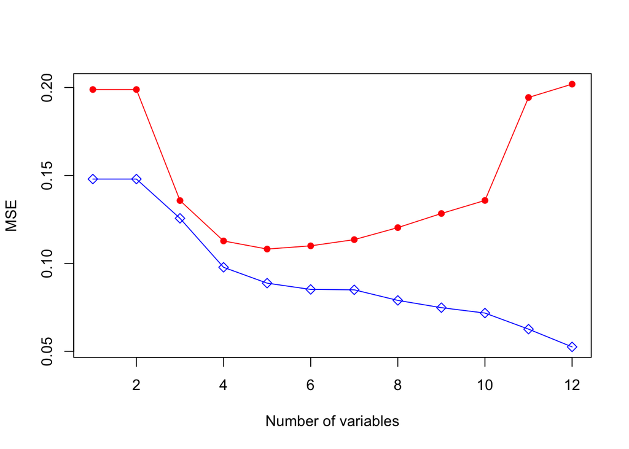

```r
n <- dim(birthweight)[1]
p <- dim(birthweight)[2] - 1

ntrain <- round(n * 0.6)
set.seed(598)
train.id <- sample(1:n, ntrain)

train.MSE <- rep(0, p)
test.MSE  <- rep(0, p)

train.Y <- birthweight[train.id, 2]
test.Y  <- birthweight[-train.id, 2]

for (i in 1:p) {
  var_id <- c(1:i, (p + 1))
  var_id <- var_id[var_id != 2]   # remove the response column
  myfit  <- lm(birthweight[train.id, 2] ~ ., data = birthweight[train.id, var_id])

  train.Y.pred <- myfit$fitted
  train.MSE[i] <- mean((train.Y - train.Y.pred)^2)

  test.Y.pred <- predict(myfit, newdata = birthweight[-train.id, ])
  test.MSE[i] <- mean((test.Y - test.Y.pred)^2)
}

plot(c(1, p), range(train.MSE, test.MSE), type = "n",
     xlab = "Number of variables", ylab = "MSE")
points(train.MSE, col = "blue", pch = 5)
lines(train.MSE, col = "blue")
points(test.MSE, col = "red", pch = 16)
lines(test.MSE, col = "red")
```

In this particular split the test MSE first declines and later rises, illustrating the classic overfitting behavior. In general we expect the training-error curve (blue) to be monotonically decreasing, while the test-error curve (red) may eventually increase.

#### Test for Outliers

We apply the Bonferroni outlier test based on externally studentized residuals:

```r
n <- dim(birthweight)[1]
p <- length(coef(birthweight.mlr.full))
birthweight.resid <- rstudent(birthweight.mlr.full)
bonferroni_cv <- qt(0.05 / (2 * n), n - p)
```

```r
birthweight.resid.sorted <- sort(abs(birthweight.resid), decreasing = TRUE)[1:10]
print(birthweight.resid.sorted)
```

```
##        2       29       34        1       28       20       42       24
## 2.068621 1.890299 1.830714 1.682375 1.645611 1.613154 1.435773 1.411769
##       19       39
## 1.347956 1.324123
```

```r
birthweight.outliers <- birthweight.resid.sorted[
  abs(birthweight.resid.sorted) > abs(bonferroni_cv)]
print(birthweight.outliers)
```

```
## named numeric(0)
```

No studentized residual exceeds the critical value, so we conclude that the data contain no outliers according to this criterion.

#### Checking Model Assumptions

Residual-versus-fitted plot:

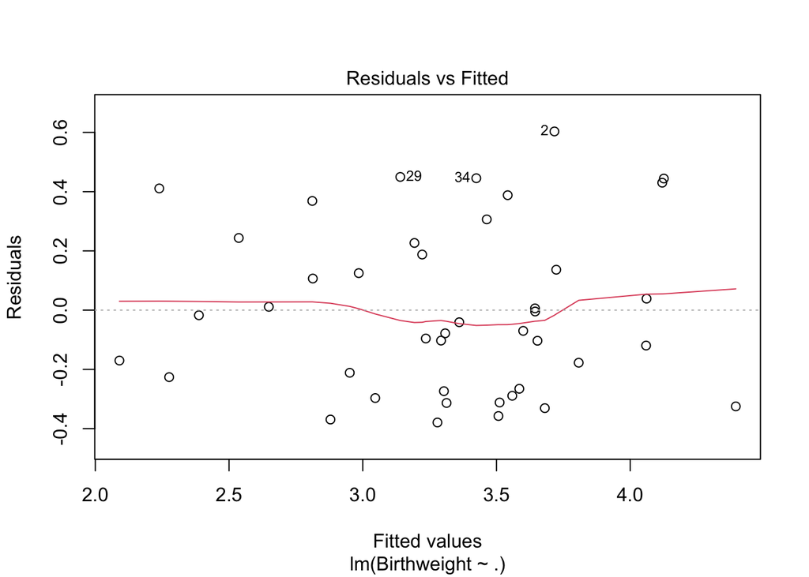

```r
plot(birthweight.mlr.full, which = 1)
```

The points scatter randomly about zero, supporting the constant-variance assumption.

Normality check:

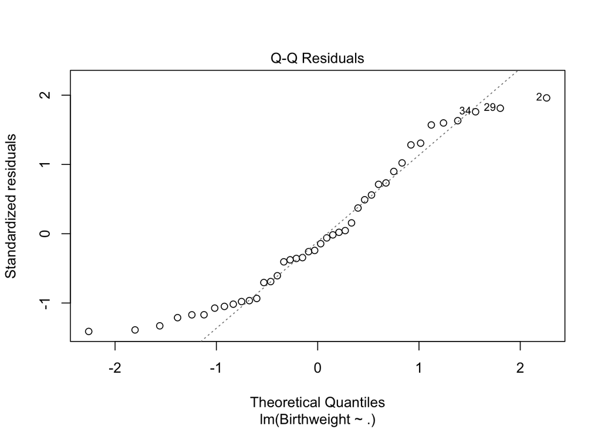

```r
plot(birthweight.mlr.full, which = 2)
```

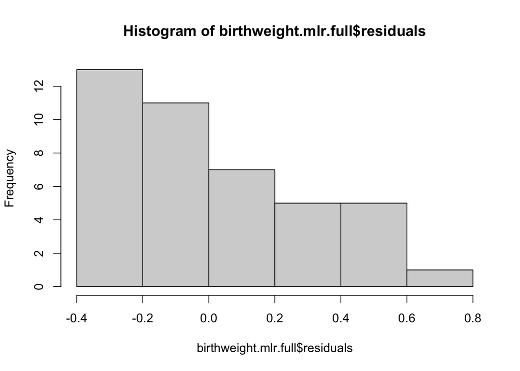

```r
hist(birthweight.mlr.full$residuals)
```

Mild departures from normality are visible.

## Collinearity: Car Seat Position Data (a Faraway data set)

Car drivers like to adjust the seat position for their own comfort. Car designers would find it helpful to know how different drivers will position the seat depending on their size and age. Researchers at the HuMoSim laboratory at the University of Michigan collected the following data on **38** drivers:

- `Age`: Driver’s age in years
- `Weight`: Driver’s weight in lbs
- `HtShoes`: Height with shoes in cm
- `Ht`: Height without shoes in cm
- `Seated`: Seated height in cm
- `Arm`: Lower arm length in cm
- `Thigh`: Thigh length in cm
- `Leg`: Lower leg length in cm
- `hipcenter`: Horizontal distance of the midpoint of the hips from a fixed location in the car (mm)

```r
library(faraway)
data(seatpos)
attach(seatpos)
```

We first fit the full model:

```r
position.full <- lm(hipcenter ~ ., data = seatpos)
summary(position.full)
```

```
##
## Call:
## lm(formula = hipcenter ~ ., data = seatpos)
##
## Residuals:
##     Min      1Q  Median      3Q     Max
## -73.827 -22.833  -3.678  25.017  62.337
##
## Coefficients:
##              Estimate Std. Error t value Pr(>|t|)
## (Intercept) 436.43213  166.57162   2.620   0.0138 *
## Age           0.77572    0.57033   1.360   0.1843
## Weight        0.02631    0.33097   0.080   0.9372
## HtShoes      -2.69241    9.75304  -0.276   0.7845
## Ht            0.60134   10.12987   0.059   0.9531
## Seated        0.53375    3.76189   0.142   0.8882
## Arm          -1.32807    3.90020  -0.341   0.7359
## Thigh        -1.14312    2.66002  -0.430   0.6706
## Leg          -6.43905    4.71386  -1.366   0.1824
## ---
## Signif. codes:  0 '***' 0.001 '**' 0.01 '*' 0.05 '.' 0.1 ' ' 1
##
## Residual standard error: 37.72 on 29 degrees of freedom
## Multiple R-squared:  0.6866, Adjusted R-squared:  0.6001
## F-statistic:  7.94 on 8 and 29 DF,  p-value: 1.306e-05
```

The overall $F$-test is highly significant ($p = 1.3 \times 10^{-5}$), yet none of the individual $t$-tests reaches significance. This pattern is a classic warning sign of collinearity.

The correlation matrix confirms the problem:

```r
round(cor(seatpos), digits = 2)
```

```
##             Age Weight HtShoes    Ht Seated   Arm Thigh   Leg hipcenter
## Age        1.00   0.08   -0.08 -0.09  -0.17  0.36  0.09 -0.04      0.21
## Weight     0.08   1.00    0.83  0.83   0.78  0.70  0.57  0.78     -0.64
## HtShoes   -0.08   0.83    1.00  1.00   0.93  0.75  0.72  0.91     -0.80
## Ht        -0.09   0.83    1.00  1.00   0.93  0.75  0.73  0.91     -0.80
## Seated    -0.17   0.78    0.93  0.93   1.00  0.63  0.61  0.81     -0.73
## Arm        0.36   0.70    0.75  0.75   0.63  1.00  0.67  0.75     -0.59
## Thigh      0.09   0.57    0.72  0.73   0.61  0.67  1.00  0.65     -0.59
## Leg       -0.04   0.78    0.91  0.91   0.81  0.75  0.65  1.00     -0.79
## hipcenter  0.21  -0.64   -0.80 -0.80  -0.73 -0.59 -0.59 -0.79      1.00
```

Many predictors are strongly correlated with one another (e.g., $\operatorname{Corr}(\texttt{Leg},\texttt{HtShoes}) = 0.91$).

Because the condition number is not scale-invariant, we first standardize the predictors (excluding the intercept column):

```r
x <- model.matrix(position.full)[, -1]
x <- scale(x)          # centers and scales
```

```r
eigenvalues.x <- eigen(crossprod(x))
sqrt(eigenvalues.x$values[1] / eigenvalues.x$values[8])
```

```
## [1] 59.7662
```

The condition number is approximately 60 (well above the conventional threshold of 30), confirming collinearity.

Variance inflation factors tell the same story:

```r
round(vif(position.full), digits = 2)
```

```
##     Age  Weight HtShoes      Ht  Seated     Arm   Thigh     Leg
##    2.00    3.65  307.43  333.14    8.95    4.50    2.76    6.69
```

The standard error of the `HtShoes` coefficient is inflated by a factor of roughly $\sqrt{307} \approx 17.5$.

A practical way forward is to examine pairwise relationships and perform partial $F$-tests:

```r
cor(Seated + Thigh, Ht)
```

```
## [1] 0.9389819
```

```r
cor(Seated + Leg, Ht)
```

```
## [1] 0.965607
```

```r
cor(Seated + Arm, Ht)
```

```
## [1] 0.9465523
```

```r
position.red1 <- lm(hipcenter ~ Age + Weight + Ht + Seated, data = seatpos)
summary(position.red1)
```

```
##
## Call:
## lm(formula = hipcenter ~ Age + Weight + Ht + Seated, data = seatpos)
##
## Residuals:
##     Min      1Q  Median      3Q     Max
## -90.869 -21.163  -3.144  26.773  59.423
##
## Coefficients:
##              Estimate Std. Error t value Pr(>|t|)
## (Intercept) 478.65890  159.73362   2.997  0.00515 **
## Age           0.58396    0.42573   1.372  0.17943
## Weight       -0.01535    0.31640  -0.049  0.96159
## Ht           -4.99025    1.64389  -3.036  0.00466 **
## Seated        2.04632    3.41283   0.600  0.55287
## ---
## Signif. codes:  0 '***' 0.001 '**' 0.01 '*' 0.05 '.' 0.1 ' ' 1
##
## Residual standard error: 36.83 on 33 degrees of freedom
## Multiple R-squared:  0.6599, Adjusted R-squared:  0.6186
## F-statistic: 16.01 on 4 and 33 DF,  p-value: 2.224e-07
```

```r
position.red2 <- lm(hipcenter ~ Ht, data = seatpos)
summary(position.red2)
```

```
##
## Call:
## lm(formula = hipcenter ~ Ht, data = seatpos)
##
## Residuals:
##     Min      1Q  Median      3Q     Max
## -99.956 -27.850   5.656  20.883  72.066
##
## Coefficients:
##             Estimate Std. Error t value Pr(>|t|)
## (Intercept) 556.2553    90.6704   6.135 4.59e-07 ***
## Ht           -4.2650     0.5351  -7.970 1.83e-09 ***
## ---
## Signif. codes:  0 '***' 0.001 '**' 0.01 '*' 0.05 '.' 0.1 ' ' 1
##
## Residual standard error: 36.37 on 36 degrees of freedom
## Multiple R-squared:  0.6383, Adjusted R-squared:  0.6282
## F-statistic: 63.53 on 1 and 36 DF,  p-value: 1.831e-09
```

```r
anova(position.red2, position.red1)
```

```
## Analysis of Variance Table
##
## Model 1: hipcenter ~ Ht
## Model 2: hipcenter ~ Age + Weight + Ht + Seated
##   Res.Df   RSS Df Sum of Sq      F Pr(>F)
## 1     36 47616
## 2     33 44774  3    2841.6 0.6981 0.5599
```

The partial $F$-test indicates that the simpler model containing only `Ht` is adequate relative to the larger model that also includes `Age`, `Weight` and `Seated`.